# 1. Load Data

# 2. Exploratory Data Analysis

### Insight 1: Data is 99.8% sparse

```python
# total combinations of users and movies
total_comb = ratings_df.select('userId').distinct().count() * movies_df.select('movieId').distinct().count()
print(f"Total possible user-movie combinations: {total_comb}")

rating_count = ratings_df.count()
print(f"Total ratings in dataset: {rating_count}")

sparsity = 1 - (rating_count / total_comb)
print(f"Sparsity of the ratings matrix: {sparsity:.6f}")
```

```
Total possible user-movie combinations: 17600030580
Total ratings in dataset: 32000204
Sparsity of the ratings matrix: 0.998182
```

The dataset has 99.8% sparsity, meaning that most of the elements in user-movie matrix is empty.

### Insight 2: 10% of users contribute to almost half of the ratings

```python
rating_count_per_user = ratings_df.groupBy('userId').count().withColumnRenamed('count', 'rating_count').toPandas()
rating_count_per_user.info()
```

```
<class 'pandas.core.frame.DataFrame'>
RangeIndex: 200948 entries, 0 to 200947
Data columns (total 2 columns):
 #   Column        Non-Null Count   Dtype
---  ------        --------------   -----
 0   userId        200948 non-null  int32
 1   rating_count  200948 non-null  int64
dtypes: int32(1), int64(1)
memory usage: 2.3 MB
```

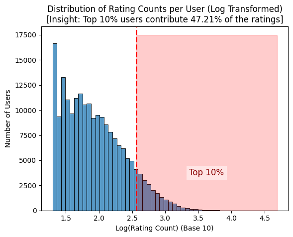

```python
cutoff_value = rating_count_per_user['rating_count'].quantile(0.90)
cutoff_log = np.log10(cutoff_value)

top_10_users = rating_count_per_user[rating_count_per_user['rating_count'] >= cutoff_value]
total_ratings = rating_count_per_user['rating_count'].sum()
top_10_contribution = top_10_users['rating_count'].sum()
contribution_pct = (top_10_contribution / total_ratings) * 100

ax = sns.histplot(np.log10(rating_count_per_user['rating_count']), bins=50, kde=False)
y_bottom, y_top = ax.get_ylim()
x_left, x_right = ax.get_xlim()
ax.axvline(x=cutoff_log, color='r', linestyle='--', linewidth=2)
midpoint_x = cutoff_log + (x_right - cutoff_log) / 2
plt.fill_betweenx([0, ax.get_ylim()[1]], cutoff_log, ax.get_xlim()[1], color='red', alpha=0.2)
plt.text(x=midpoint_x, y=y_top * 0.2, s='Top 10%', fontsize=12, color='darkred', ha='center', bbox=dict(facecolor='white', alpha=0.5, edgecolor='none'))
plt.title(f'Distribution of Rating Counts per User (Log Transformed)\n[Insight: Top 10% users contribute {contribution_pct:.2f}% of the ratings]')
plt.xlabel('Log(Rating Count) (Base 10)')
plt.ylabel('Number of Users')
plt.show();
```

```
Gini Coefficient of Ratings Distribution among Users: 59.37%
```

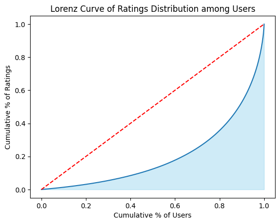

```python
# gini coefficient to measure inequality in ratings distribution among users

cumulative_ratings = rating_count_per_user['rating_count'].sort_values().cumsum()
cumulative_ratings_pct = cumulative_ratings / cumulative_ratings.iloc[-1]
cumulative_users_pct = np.arange(1, len(rating_count_per_user) + 1) / len(rating_count_per_user)
gini_coefficient = (0.5 - np.trapezoid(cumulative_ratings_pct, cumulative_users_pct)) / 0.5

print(f"Gini Coefficient of Ratings Distribution among Users: {gini_coefficient*100:.2f}%")

sns.lineplot(x=cumulative_users_pct, y=cumulative_ratings_pct)
sns.lineplot(x=[0,1], y=[0,1], color='red', linestyle='--')
plt.fill_between(cumulative_users_pct, cumulative_ratings_pct, color='skyblue', alpha=0.4)
plt.title('Lorenz Curve of Ratings Distribution among Users')
plt.xlabel('Cumulative % of Users')
plt.ylabel('Cumulative % of Ratings')
plt.show();
```

A high gini coefficient and Lorenz curve that bows very further from the red dotted lines shows inequality in rating count between users.

### Insight 3: Almost all of the ratings are for 10% of top movies

```python
rating_count_per_movie = ratings_df.groupBy('movieId').count().withColumnRenamed('count', 'rating_count').toPandas()
rating_count_per_movie.info()
```

```
<class 'pandas.core.frame.DataFrame'>
RangeIndex: 84432 entries, 0 to 84431
Data columns (total 2 columns):
 #   Column        Non-Null Count  Dtype
---  ------        --------------  -----
 0   movieId       84432 non-null  int32
 1   rating_count  84432 non-null  int64
dtypes: int32(1), int64(1)
memory usage: 989.6 KB
```

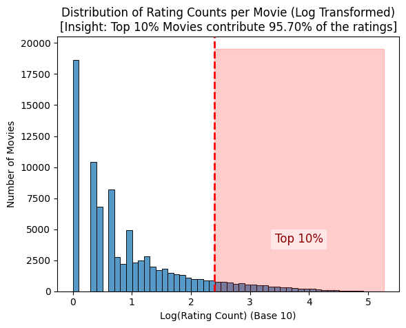

```python
cutoff_value = rating_count_per_movie['rating_count'].quantile(0.90)
cutoff_log = np.log10(cutoff_value)

top_10_movies = rating_count_per_movie[rating_count_per_movie['rating_count'] >= cutoff_value]
total_ratings = rating_count_per_movie['rating_count'].sum()
top_10_contribution = top_10_movies['rating_count'].sum()
contribution_pct = (top_10_contribution / total_ratings) * 100

ax = sns.histplot(np.log10(rating_count_per_movie['rating_count']), bins=50, kde=False)
y_bottom, y_top = ax.get_ylim()
x_left, x_right = ax.get_xlim()
ax.axvline(x=cutoff_log, color='r', linestyle='--', linewidth=2)
midpoint_x = cutoff_log + (x_right - cutoff_log) / 2
plt.fill_betweenx([0, ax.get_ylim()[1]], cutoff_log, ax.get_xlim()[1], color='red', alpha=0.2)
plt.text(x=midpoint_x, y=y_top * 0.2, s='Top 10%', fontsize=12, color='darkred', ha='center', bbox=dict(facecolor='white', alpha=0.5, edgecolor='none'))
plt.title(f'Distribution of Rating Counts per Movie (Log Transformed)\n[Insight: Top 10% Movies contribute {contribution_pct:.2f}% of the ratings]')
plt.xlabel('Log(Rating Count) (Base 10)')
plt.ylabel('Number of Movies')
plt.show();
```

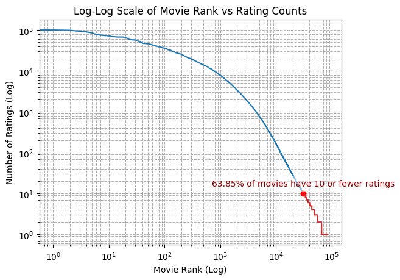

```python
rating_count_per_movie = rating_count_per_movie.sort_values(by='rating_count', ascending=False).reset_index(drop=True)
nonpopular_movies_idx = rating_count_per_movie[rating_count_per_movie['rating_count'] <= 10].index
nonpopular_movies_pct = (len(nonpopular_movies_idx) / len(rating_count_per_movie)) * 100
sorted_counts = rating_count_per_movie['rating_count'].sort_values(ascending=False).values
x_rank = np.arange(len(sorted_counts))

plt.loglog(x_rank[:nonpopular_movies_idx[0]+1], sorted_counts[:nonpopular_movies_idx[0]+1], color='tab:blue')
plt.plot(nonpopular_movies_idx[0], 10, 'o', color='red')
plt.loglog(x_rank[nonpopular_movies_idx[0]:], sorted_counts[nonpopular_movies_idx[0]:], color='tab:red', label='Movies with <=10 ratings')
plt.text(x=nonpopular_movies_idx[0], y=15, s=f"{nonpopular_movies_pct:.2f}% of movies have 10 or fewer ratings", fontsize=10, color='darkred', ha='center', bbox=dict(facecolor='white', alpha=0.5, edgecolor='none'))
plt.title("Log-Log Scale of Movie Rank vs Rating Counts")

plt.xlabel("Movie Rank (Log)")
plt.ylabel("Number of Ratings (Log)")
plt.grid(True, which="both", ls="--")

plt.show()
```

From this graph, we can see that large count of ratings comes from only a small percentage of the whole movies, and 63.85% of movies have 10 or fewer ratings.

```
Gini Coefficient of Ratings Distribution among movies: 95.24%
```

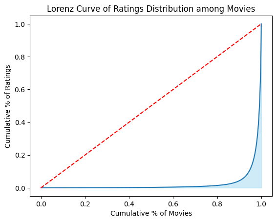

```python
# gini coefficient to measure inequality in ratings distribution among movies

cumulative_ratings = rating_count_per_movie['rating_count'].sort_values().cumsum()
cumulative_ratings_pct = cumulative_ratings / cumulative_ratings.iloc[-1]
cumulative_movies_pct = np.arange(1, len(rating_count_per_movie) + 1) / len(rating_count_per_movie)
gini_coefficient = (0.5 - np.trapezoid(cumulative_ratings_pct, cumulative_movies_pct)) / 0.5

print(f"Gini Coefficient of Ratings Distribution among movies: {gini_coefficient*100:.2f}%")

sns.lineplot(x=cumulative_movies_pct, y=cumulative_ratings_pct)
sns.lineplot(x=[0,1], y=[0,1], color='red', linestyle='--')
plt.fill_between(cumulative_movies_pct, cumulative_ratings_pct, color='skyblue', alpha=0.4)
plt.title('Lorenz Curve of Ratings Distribution among Movies')
plt.xlabel('Cumulative % of Movies')
plt.ylabel('Cumulative % of Ratings')
plt.show();
```

The inequality is also confirmed with a very high gini coefficient (95.24%).